# Nuclear Power: Miracle or Menace?

# Preamble

**Nuclear energy** emerged out of atomic science advancements during WWII and enjoyed several decades of significant expansion to address industrializing nations’ energy demands. Over many years, nuclear energy saw significant growth worldwide; countries invested heavily in nuclear infrastructure, using its power to drive advancements in cities, medicine, and industry. Nuclear energy appeared limitless in its potential, sparking imaginations everywhere.  
The data used to develop this project come from Ember’s Yearly Electricity Data; Ember’s European Electricity Review; Energy Institute Statistical Review of World Energy and ElectricityMap.

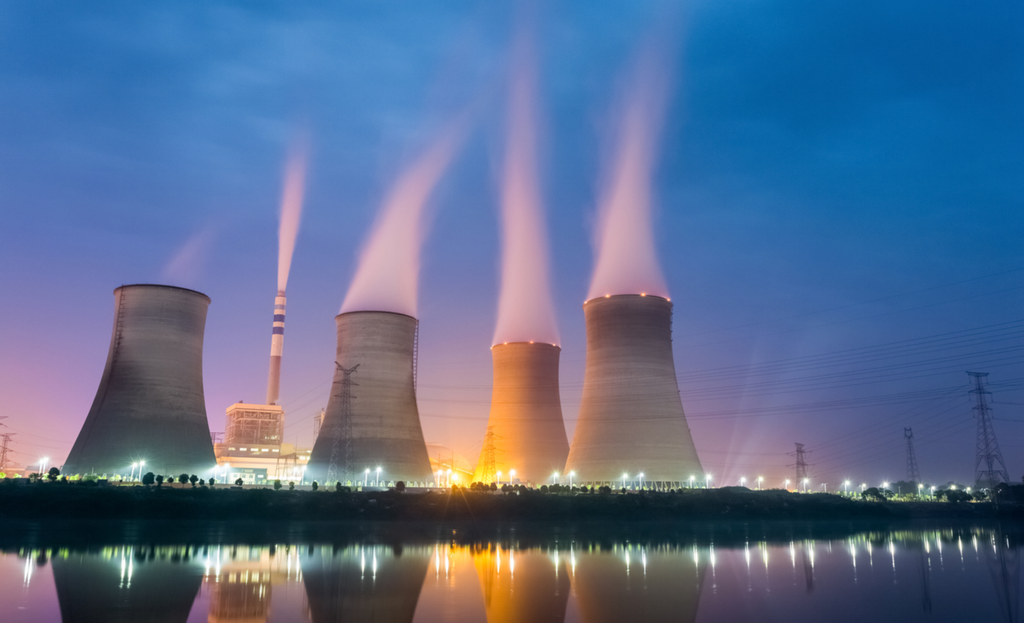

# Deepening into the analysis

This graph tracks the growth of nuclear power as a source of global energy generation since the 1960s. It shows that nuclear power first began emerging as a new technology for electricity production in the early 1960s. From this starting point, nuclear generation ramped up rapidly during the following decades of the 1970s and 1980s as more reactors came online worldwide.  
Today, worldwide the nuclear energy is providing about 10% of global electricity generation (source: IEA); in Europe Nuclear plants generated around 21.8% of the total electricity produced in 2022 (source: World Nuclear Association).

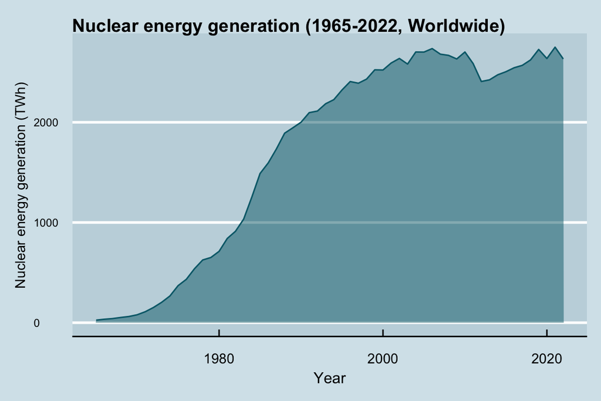

Nuclear energy generation (1965-2022, Worldwide)

In 2022, Europe produced around **1000TWh** of electricity from nuclear power plants.

It is important to remark that Nuclear power plants themselves do not directly emit greenhouse gases like CO2 during electricity generation, while N.P.P. has environmental impacts throughout its life cycle, including mining uranium fuel, plant construction and decommissioning, the actual electricity generation process is considered a low-carbon source of energy.

Life-cycle assessment studies estimate the average carbon footprint of nuclear power to be around 12 grams of CO2 equivalent per kilowatt-hour (gCO2eq/kWh) in U.S.A (Source: IPCC 2014) and 5 grams of CO2 equivalent per kilowatt-hour (gCO2eq/kWh) in Europe (Source: UNECE 2022).  
This is significantly lower than the emissions of most other electricity generation sources, including fossil fuels like coal (around 820 gCO2eq/kWh) and natural gas (around 400 gCO2eq/kWh) (Source: EU-ETS, ENTSO-E 2022; Oberschelp, Christopher, et al. “Global emission hotspots of coal power generation.).  
Overall, while nuclear power is not completely emission-free, it offers a significant advantage in terms of reduced greenhouse gas emissions compared to traditional fossil fuel sources.

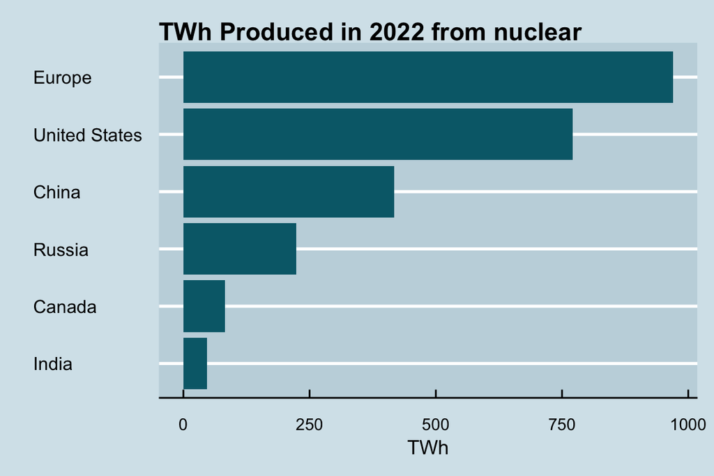

Twh produced from nuclear in 2022, Best aereas plot

Fossil fuels like coal, oil, and brown coal generally have higher death rates due to factors like air pollution from emissions and accidents during mining and extraction.  
Renewable energy sources like solar, wind, and hydropower have significantly lower death rates. Nuclear power also has a very low death rate, due to the very high level of security offered (IAEA), and also because the industry does take full responsibility for all its waste, including used nuclear fuel and other radioactive materials. This includes safe storage, reprocessing in some cases, and research into long-term disposal solutions like deep geological repositories.  
**Fossil fuels:** They produce waste in the form of air and water pollutants, greenhouse gases, and solid waste like ash. While regulations aim to minimize these impacts, challenges remain in managing and mitigating the long-term effects.  
**Renewables:** They generally have a lower environmental footprint, but still generate waste like decommissioned equipment, manufacturing byproducts, and end-of-life solar panels and wind turbine blades. This waste requires proper management and recycling strategies.

Source: Markandya & Wilkinson (2007); Sovacool et al. (2016); UNSCEAR (2008; & 2018)

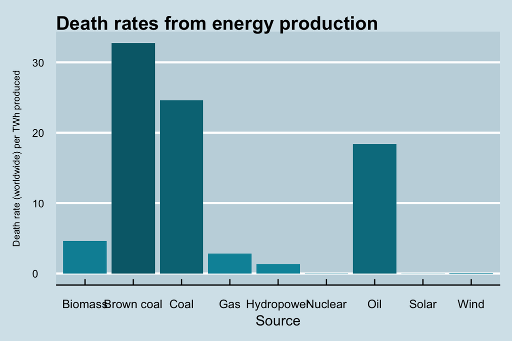

Death rates of different energy sources

The value of 0.03 for nuclear is low… and incorrect; the value should be even **smaller**. [read here](https://www.collectifission.nl/en/2024/02/why-our-world-in-data-is-wrong-on-nuclear-safety/)

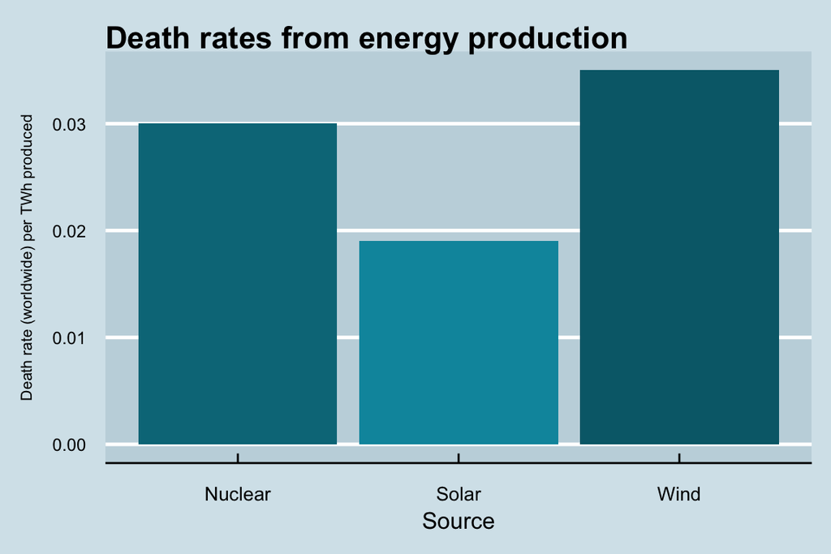

Death rates of different energy sources

**Upper-middle-income countries:**  
Some upper-middle-income countries have been expanding their nuclear power capacity in recent years. Examples include China, India, and Vietnam. This is primarily driven by factors like:  
**Meeting growing energy demands:** Nuclear power offers a reliable and baseload source of electricity without significant greenhouse gas emissions.  
**Securing energy independence:** Some countries aim to reduce dependence on fossil fuels and imported energy sources. Technological advancements: Advancements in reactor designs and safety measures address certain concerns associated with nuclear power.

**High-income countries:** Some high-income countries, especially in Europe, have indeed reduced their reliance on nuclear power. Examples include Germany and Belgium. This trend is driven by:  
**Public concerns:** Concerns about safety risks and radioactive waste disposal have influenced public opinion and policy decisions.  
**Renewable energy alternatives:** The growing cost-competitiveness and environmental benefits of renewable energy sources are making them increasingly attractive .  
**Phasing out plans:** Some countries have set specific timelines for phasing out nuclear power based on national policies and energy goals.

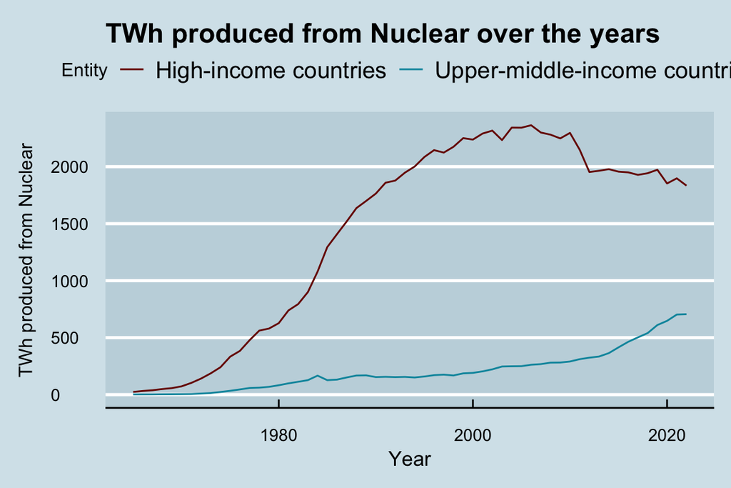

TWh produced from nuclear over the years

# Analysis Maps

This map depicts the global distribution of terawatt-hours (TWh) of electricity generated from nuclear power plants in 2022. Each country or region is shaded according to its total nuclear power output, with darker shades representing higher production levels.

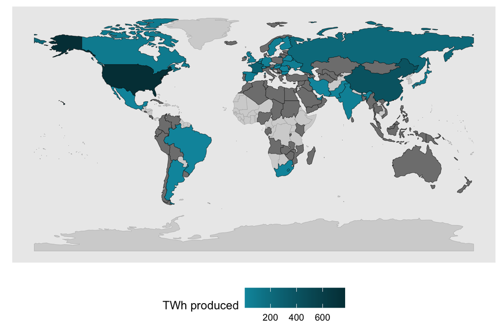

World map of the Twh produced from nuclear

Since transport and heating tend to be harder to decarbonize – they are more reliant on oil and gas – nuclear and renewables tend to have a **higher share** in the electricity mix versus the total energy mix.

This chart shows the share of electricity that comes from nuclear sources.

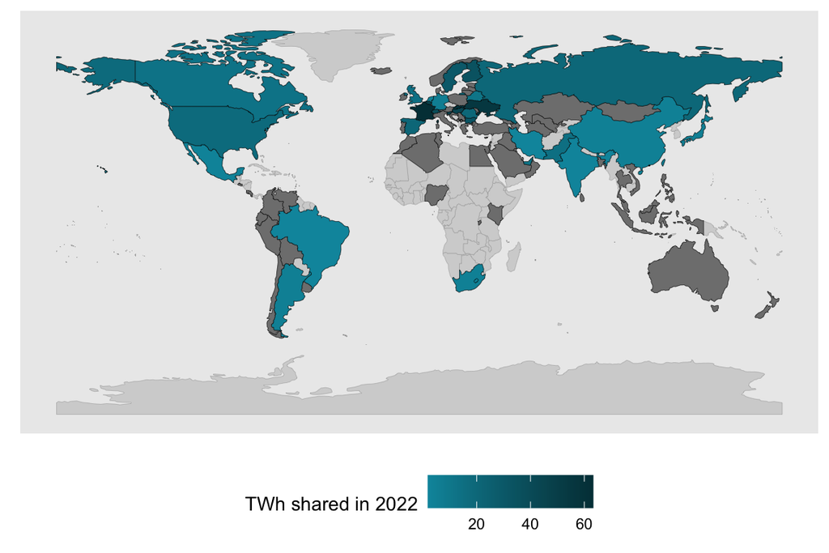

World map of shared energy from nuclear source in 2022

This map shows the per capita energy consumption from nuclear power in different countries in 2022.  
The chart also shows that there is a significant variation in per capita energy consumption from nuclear power between different regions of the world. For example, the average per capita energy consumption from nuclear power in Europe is much higher than the average per capita energy consumption from nuclear power in Asia.

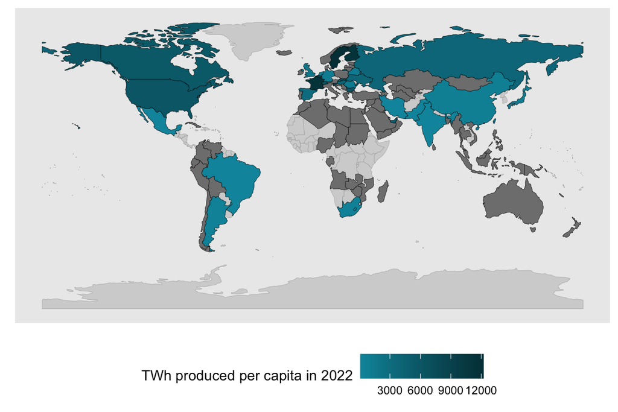

World map of per capita energy from nuclear source in 2022

# France vs Germany approach of clean energy production

**Germany:**  
Took the decision to phase out all nuclear power by 2022 following the Fukushima disaster in Japan. This was part of an “energiewende” or energy transition plan to shift completely to renewable sources. Germany has invested heavily in solar and wind, which now provide over 40% of its electricity.

This section of the research delves into the strategies of two nations striving towards achieving carbon-neutral energy production by the 2050 net-zero deadline. It will examine, in one instance, a nation that has heavily invested in nuclear power and, in the other instance, a nation that has committed substantial resources, exceeding 600 billion dollars, to the installation of renewable energy sources such as solar and wind farms.

The data presented in the graph suggests a consistent disparity in the carbon intensity of electricity generation between Germany and France throughout 2023. Notably, Germany’s electricity production consistently exhibited a **higher carbon footprint** compared to France.

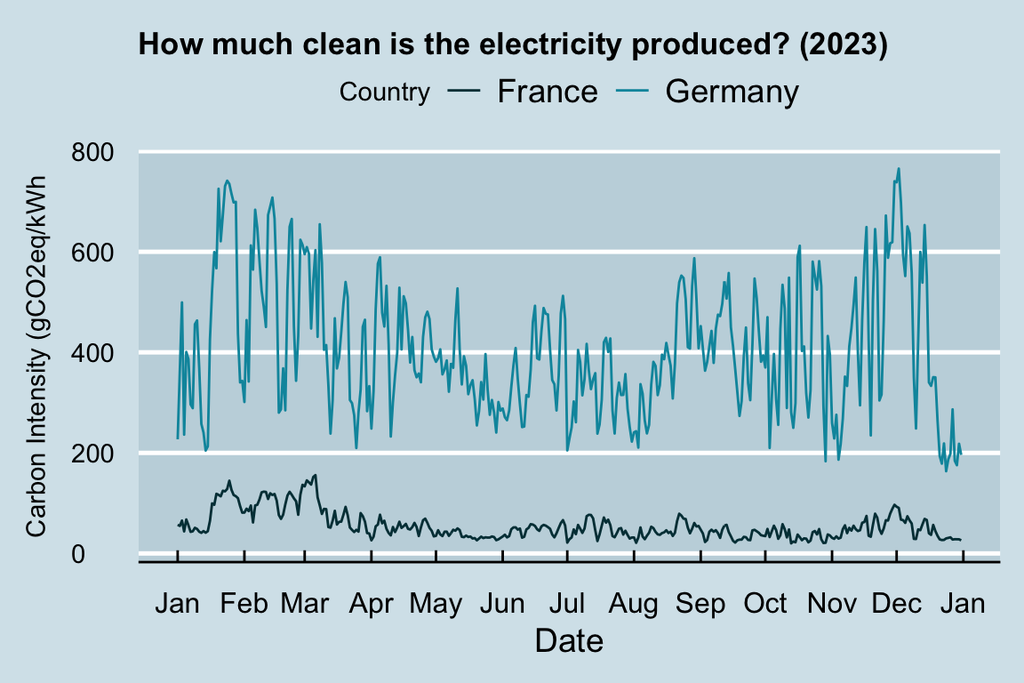

How much clean is the electricity produced? (2023)

Despite surpassing France in the total amount of electricity generated from renewable energy sources (REN), Germany **still** exhibited a higher carbon intensity in its overall electricity production. *why?*

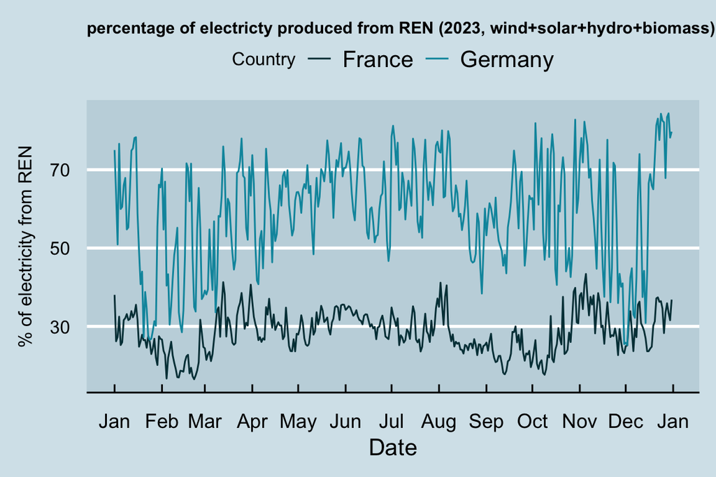

percentage of electricty produced from REN (2023, wind+solar+hydro+biomass)

The percentage of electricity generation from low-carbon sources in France consistently **surpassed** that of Germany throughout the analyzed period.

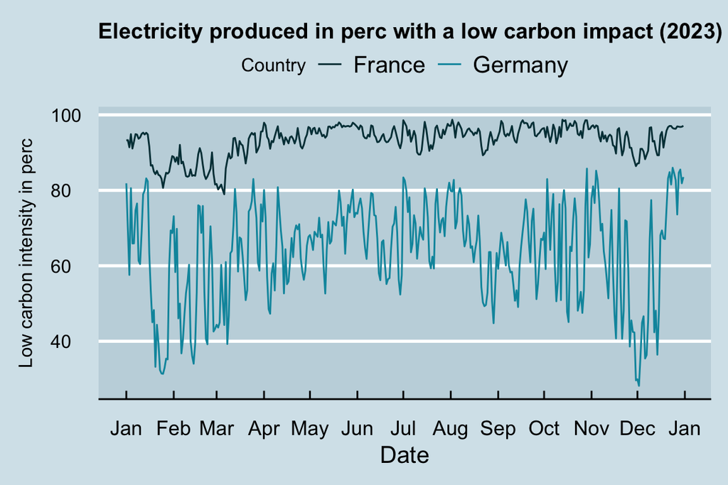

Electricity produced in perc with a low carbon impact (2023)

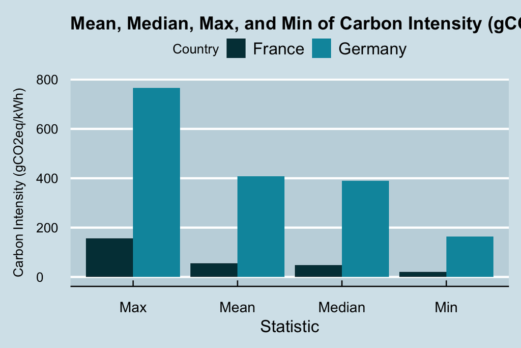

The presented graph effectively illustrates the difference in the carbon intensity of electricity generation between France and Germany. It is evident that France consistently exhibits a **lower carbon footprint** for its electricity production compared to Germany. This suggests a potential advantage for France in terms of contributing to climate change mitigation efforts.

Other Statistics of Carbon Intensity for France

| Country | Value | Statistic |
| --- | --- | --- |
| France | 27.797 | SD |
| France | 30.170 | IQR |
| France | 135.760 | Range |
| France | 772.654 | Variance |
| France | 1.408 | Skewness |
| France | 1.517 | Kurtosis |
| France | 0.503 | CV |

Other Statistics of Carbon Intensity for Germany

| Country | Value | Statistic |
| --- | --- | --- |
| Germany | 133.533 | SD |
| Germany | 191.360 | IQR |
| Germany | 601.900 | Range |
| Germany | 17831.126 | Variance |
| Germany | 0.529 | Skewness |
| Germany | -0.406 | Kurtosis |
| Germany | 0.327 | CV |

This table presents additional statistical measures of carbon intensity. It includes statistics such as standard deviation, interquartile range, and skewness, which provide insights into the variability, distribution, and symmetry of the carbon intensity data.

The observed disparity in carbon intensity between France and Germany can be partly explained by their differing energy mixes. Notably, despite significant investments in renewable energy sources, **Germany still relied heavily on coal in 2023**, accounting for 32% of its energy mix. This dependence on a carbon-intensive fossil fuel like coal significantly contributes to Germany’s higher carbon intensity compared to France, which has a more diversified energy mix with a larger share of low-carbon sources.

[interactive chart not shown]

Energy mix of France (2023)

[interactive chart not shown]

Energy mix of Germany (2023)

# Network science

Europe faces important choices as it works to create a clean and environmentally friendly energy system. One key part of this involves understanding how power moves between different countries.  
This study looks at how electricity flows across Europe using a technique called “network science”. Network science allows us to represent this flow as a network and learn from its structure. By analyzing the European electricity network, it’s possible to focus on the centrality and power of this grid. Studying Europe’s electricity network using network science can provide useful insights that may help to undesrtand better the role of countries inside the system.

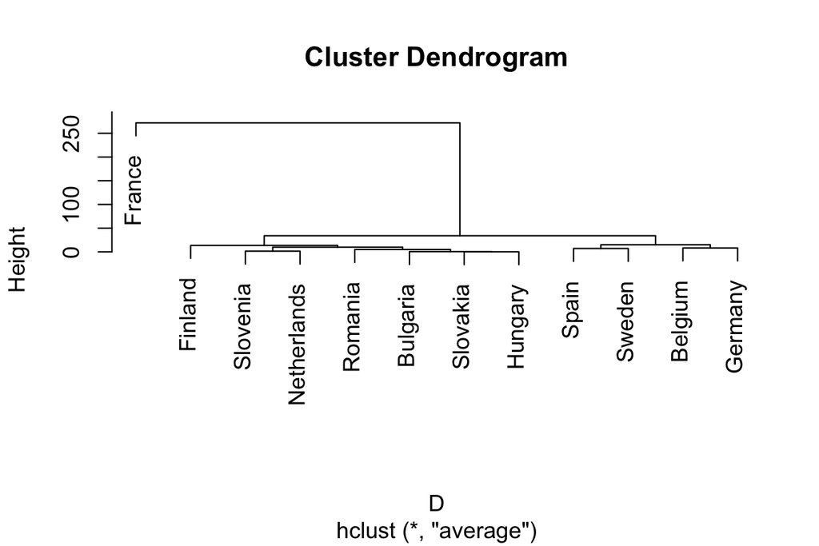

Group analysis of EU electricity from nuclear source

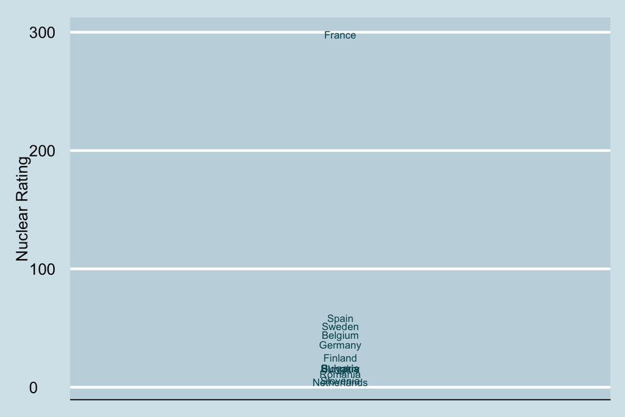

Country ranking of nuclear energy

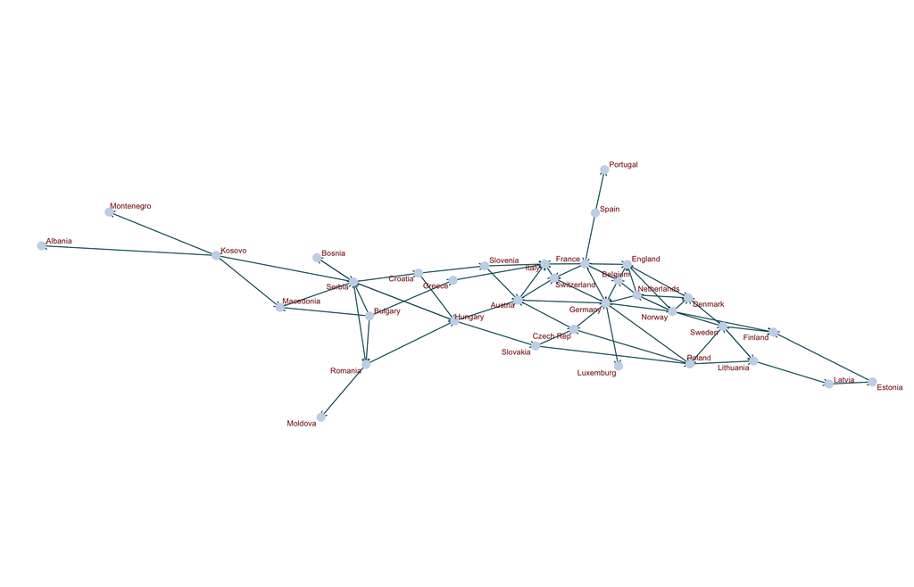

Graph of EU electricity share newtwork

Networks are made up of nodes (individuals or entities) linked by connections of some kind (in this case, electricity share). In social networks, more central or well-connected nodes tend to have greater influence and power within the network. Their actions can significantly impact others. There are different measures of centrality that help identify the most important nodes in a network, in this project I have based the centrality and power measure on the built-in script of the ‘igraph’ library. **Centrality (Katz):** Measures the influence of a vertex within a network, taking into account both direct and indirect paths to other vertices.  
**Power:** It calculates the power measure for each vertex in the graph. The output is a vector of power measures for each vertex.  
The choice of alpha = 0.9 for alpha centrality and exponent = 0.1 for power centrality reflects a balance between emphasizing local interactions (alpha centrality) while also considering global information flow (power centrality) in the network.

Sort top-5 states according to centrality:

```
     Norway      France Netherlands      Serbia     Germany
      5.233       4.361       4.361       4.361       3.489
```

Sort top-5 states according to power:

```
     Norway Netherlands      Serbia      France     Bulgary
       2.36        2.07        1.97        1.87        1.58
```

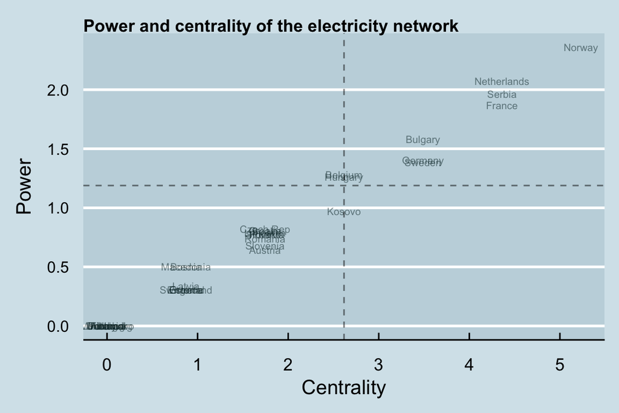

Centrality and Power of EU electricity share network

Countries such as Portugal exhibit lower centrality and power due to their limited network connectivity. Conversely, nations like Norway, France, and Germany possess greater centrality and power values, likely attributable to their more extensive network connections and potential for electricity transmission.

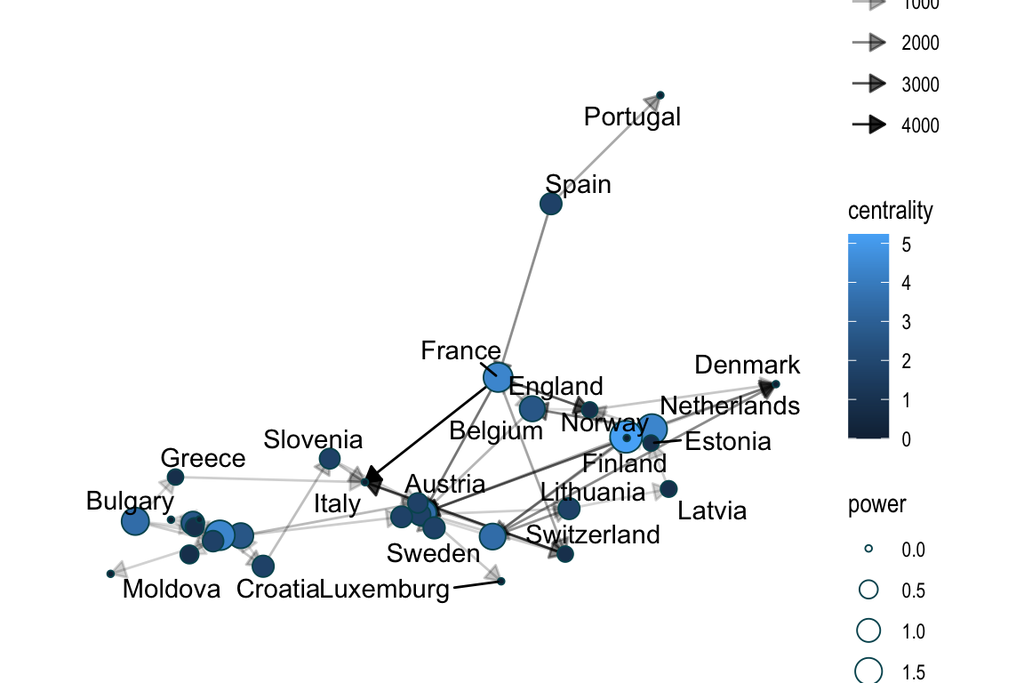

Graph Centrality and Power of EU electricity share network

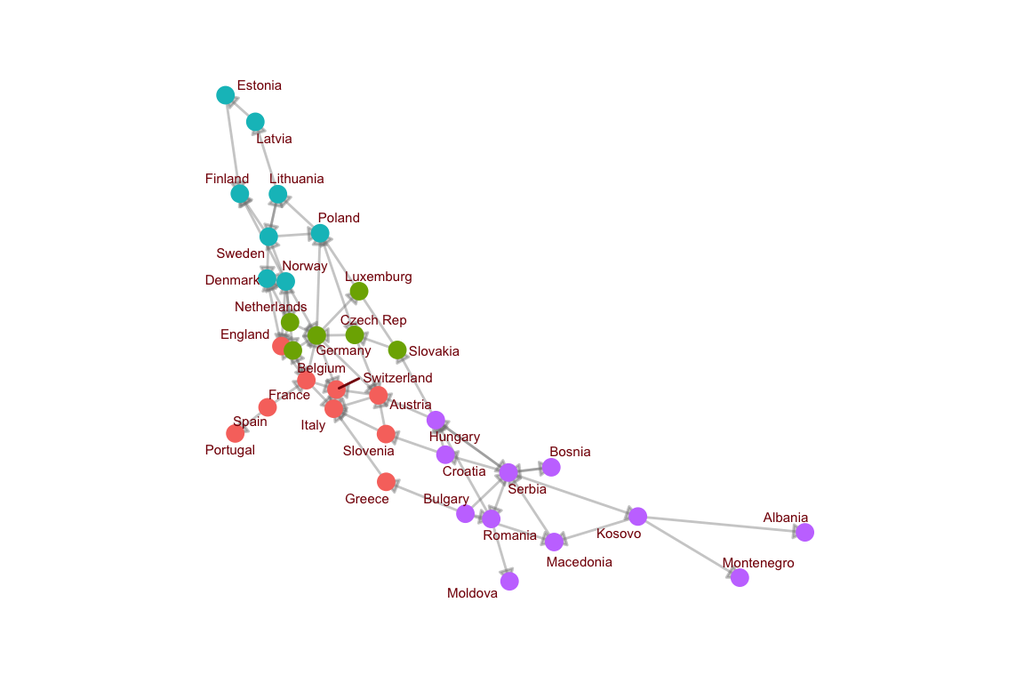

Community Detection of the network

```
         optimal    leading_eigen         walktrap       label_prop
    0.5135574717     0.4957826445     0.4700801070     0.4461374487
edge_betweenness          infomap        spinglass
    0.3645093490     0.1159476937     0.0007145294
```

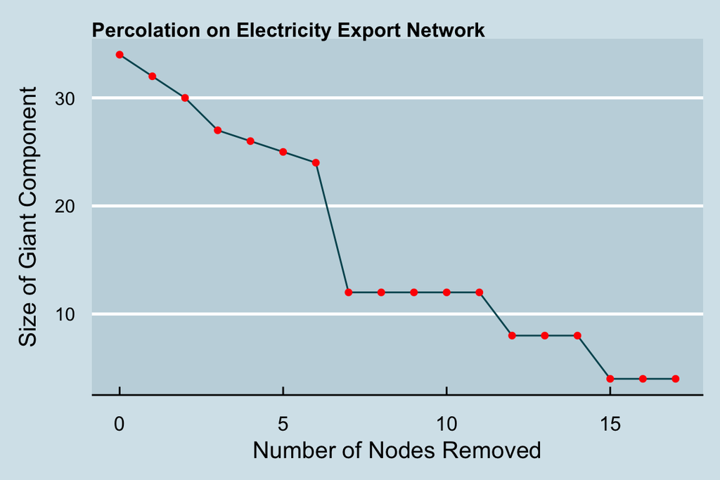

Percolation of the network

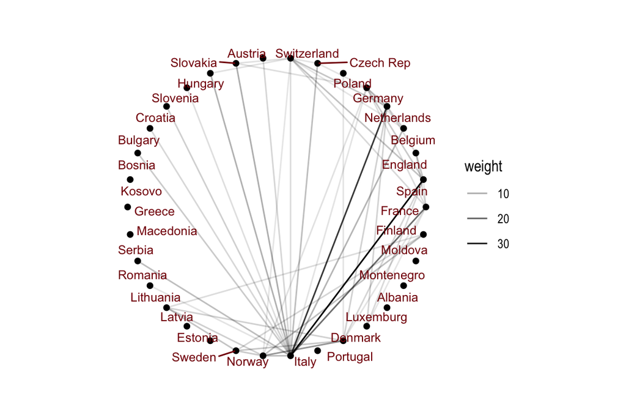

Similarity of the network

# Conclusion

A Critical Role for Nuclear in Achieving Net Zero.

An examination of reports from leading organizations like the IPCC, IEA, and IAEA highlights a strong rationale for expanding our reliance on nuclear energy as a critical component of the clean energy transition. While achieving a 100% renewable energy system may appear attractive on the surface, it remains an unrealistic and potentially impractical goal for most nations in the near future.

Therefore, it is crucial to explore and implement a multifaceted approach that leverages the strengths of various low-carbon energy sources, including nuclear power. This will allow us to achieve the ambitious target of net-zero emissions by 2050 in a realistic and sustainable manner.

# Presentation

Click **Here** to start.

# About

**Author of this project**: Andrea Turchet  
- Andrea’s [GitHub](https://github.com/AndreaTurchet)